# Sensitivity Assignment 3 - 1D systems

# 4. GSA variation analysis

The GSA variation analysis for the state at all nodes is time consuming. For that reason we will limit the GSA variation analysis to the data calculated by MRESULT - the groundwater level in the nature reserve.

## 4.1 Analysis of the M-sample

First we determine the basic statistics of the M-sample:

```r
VARM = var(Msample)
SDM = sd(Msample)
print(paste("variance of sample M",round(VARM,4)))
```

```
## [1] "variance of sample M 0.2441"
```

```r
print(paste("standard deviation of M",round(SDM,4)))
```

```
## [1] "standard deviation of M 0.4941"
```

Plotting the histogram:

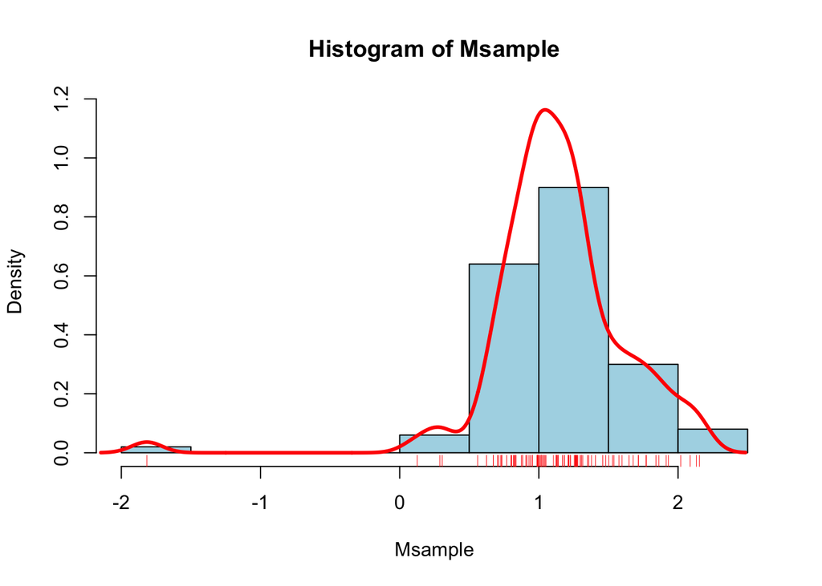

```r
smoothdensM = density(Msample)
histdataM = hist(Msample,plot=FALSE)$density
yrange = range(smoothdensM$y,histdataM)
hist(Msample,col="lightblue",prob=TRUE,ylim=yrange)
rug(Msample,col="red")
lines(smoothdensM,col="red",lwd=3)
```

You can repeat the whole analysis up to here to investigate the effect of changing the seed. The effect of changing the seed depends on the size of your parameter sample.

## 4.2 Conditional expectation of M with respect to parameters

The next step is to investigate to what extent variation in a parameter can explain variation in model result. Therefore, it is handy to combine the M-sample and the parameter-sample into one big matrix:

```r
MPsample = cbind(M=Msample,parsample)
head(MPsample)
```

```
##           M       kDl        kDr            P      Qwell        hl
## 1 1.2605155  70.12875 152.975432 0.0007907443 -0.1878875 0.9742098
## 2 0.6721567  69.77212 146.296095 0.0006987292 -0.4558072 0.9940887
## 3 1.0007681 123.04408 340.807509 0.0010926337 -0.4426630 0.9795749
## 4 0.9295858  50.42677   2.488685 0.0007671687 -0.3407795 1.0273329
## 5 1.8616263  30.96668 101.657616 0.0011886296 -0.2946325 1.0338562
## 6 0.9401496  62.39381 244.414075 0.0007993438 -0.3818607 1.0149144
```

Next we will approximate the conditional expectation of M given each of the parameters. We do this with the `linloess` function that is provided in the `samplehelpers` code. This function is based on the R-function `loess`, see Help>loess.

```r
McondkDl = linloess(M~kDl,data=MPsample)
McondkDr = linloess(M~kDr,data=MPsample)
McondP = linloess(M~P,data=MPsample)
McondQwell = linloess(M~Qwell,data=MPsample)
Mcondhl = linloess(M~hl,data=MPsample)
```

The following code provides a plot of the parameter value versus model results, with conditional expectation included, for parameter kDl:

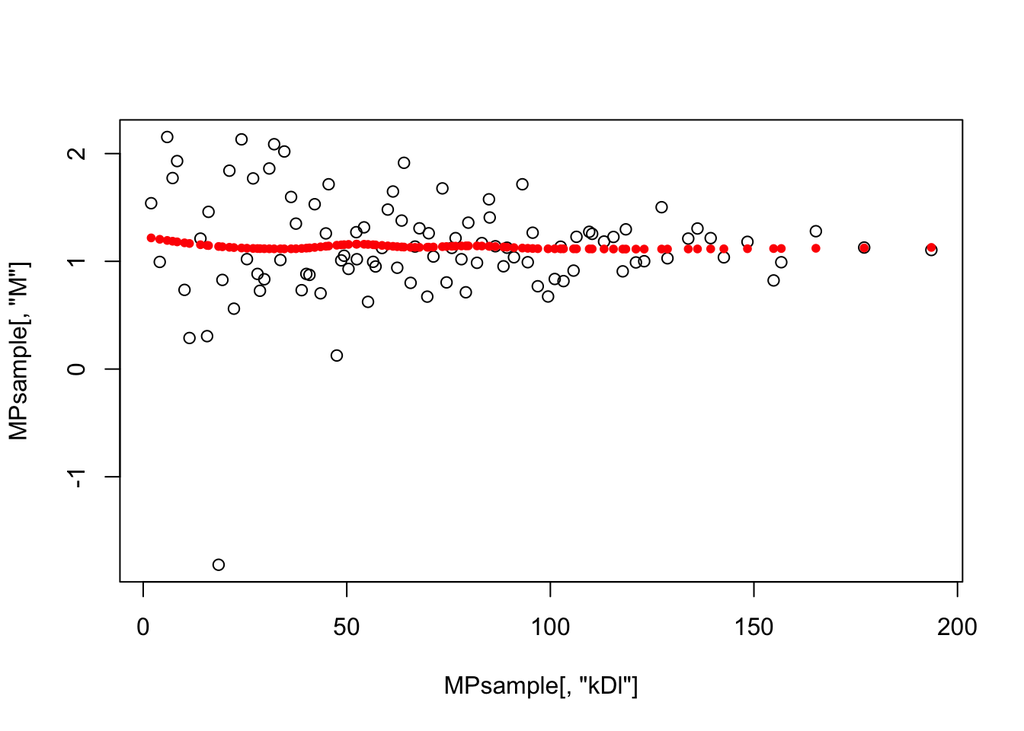

```r
plot(MPsample[,"kDl"],MPsample[,"M"])
McondkL = linloess(M~kDl,data=MPsample)
points(MPsample[,"kDl"],McondkL,pch=20,col="red")
```

Create the same plot for the other model parameters

All plots in one overview:

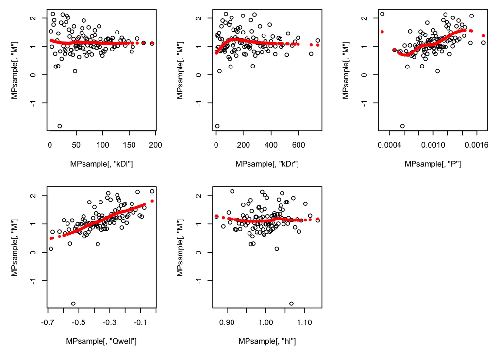

```r
old.par = par(no.readonly=TRUE)
par(mfrow=c(2,3))
par(mar=c(5,5,1,1))
plot(MPsample[,"kDl"],MPsample[,"M"])
points(MPsample[,"kDl"],McondkDl,pch=20,col="red")
plot(MPsample[,"kDr"],MPsample[,"M"])
points(MPsample[,"kDr"],McondkDr,pch=20,col="red")
plot(MPsample[,"P"],MPsample[,"M"])
points(MPsample[,"P"],McondP,pch=20,col="red")
plot(MPsample[,"Qwell"],MPsample[,"M"])
points(MPsample[,"Qwell"],McondQwell,pch=20,col="red")
plot(MPsample[,"hl"],MPsample[,"M"])
points(MPsample[,"hl"],Mcondhl,pch=20,col="red")
par(old.par)
```

Describe each plot, and estimate based on the plots which parameter you think has highest sensitivity.

Write your answer here…

A horizontal line implies that the parameter value does not explain the variation in model results at all. Those parameters where the conditional expectation shows a clear signal (either linear or non-linear) are the most sensitive ones. Based on these plots, P and Qwell can be expected to be highly sensitive, as a clear increase in M is observed with an increase in P and Qwell.

## 4.3 Contribution of the parameters to the variance of M

With the help of the `sample.vardecomp` function from the `samplehelpers` code, the analysis can now be completed:

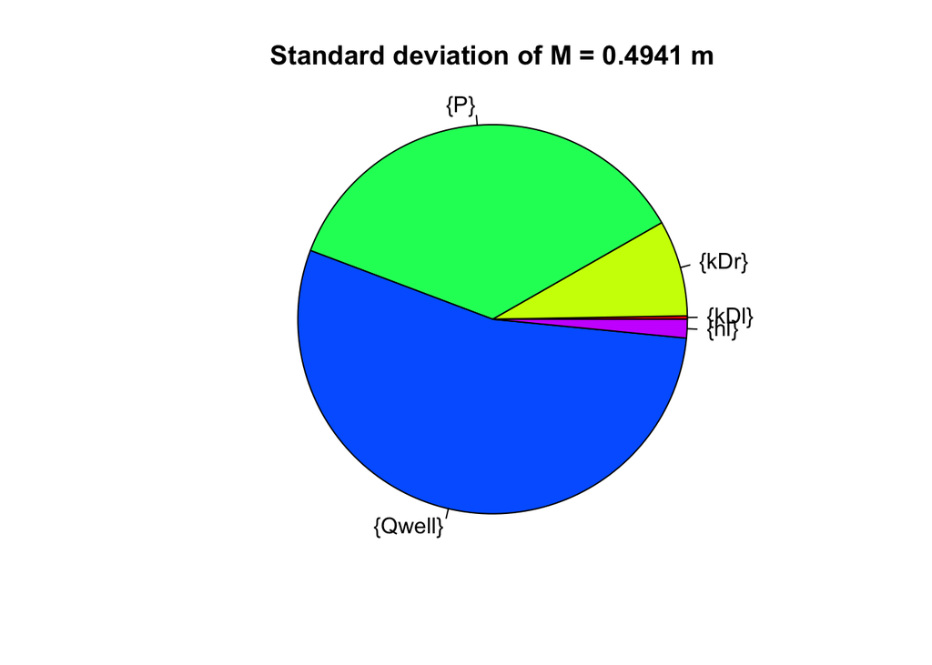

```r
ANOVA1 = sample.vardecomp(MPsample)
pie(ANOVA1,
    main=paste("Standard deviation of M =",round(SDM,4),"m"),
    col = rainbow(5),
    radius=1)
```

```r
print(ANOVA1) # the variance in M caused by each parameter
```

```
##        {kDl}        {kDr}          {P}      {Qwell}         {hl}
## 0.0004264372 0.0122302833 0.0550832306 0.0829487891 0.0023773826
```

```r
print(sqrt(ANOVA1)) # the standard deviation of M caused by each parameter
```

```
##      {kDl}      {kDr}        {P}    {Qwell}       {hl}
## 0.02065036 0.11059061 0.23469817 0.28800831 0.04875841
```

Describe the results. Does it align with your expectation based on the conditional probabilities?

Write your answer here…

Yes, clearly the parameters that showed most signal in the conditional probability are the ones with the highest contribution to the total model variance. Conceptually, the results also make sense; more rainfall means a higher groundwater level, also in the nature area. A higher extraction rate means a lower groundwater level in the nature area. In many model applications, however, the parameters do not have such a clear direct physical meaning. That makes it harder to estimate whether the sensitivity analysis results make sense or not.

# 5. Decisions made during the sensitivity analysis

In performing this sensitivity analysis, many decisions are made. Two were already discussed; the sample size and the seed. In principle, the effect of the seed should diminish when a sufficient sample size is chosen. Other decisions, however, are for instance the parameter boundaries, the normal distribution that is sampled (why not uniform?), and the variable of interest. Feel free to play around with any of these choices, and investigate how they lead to different results. It is important to keep in mind that sensitivity analysis is always only valid for the specific instance for which it was conducted: sensitive parameters for one variable of interest (e.g. groundwater level in nature area) does for example not mean that this parameter is also sensitive for another variable of interest (e.g. when one is interested in the max groundwater level).